# RUV-seq on short infection

```r
knitr::opts_chunk$set(echo = TRUE)
knitr::opts_chunk$set(include = TRUE)
knitr::opts_chunk$set(fig.width = 6)
knitr::opts_chunk$set(fig.height = 5)
library(greekLetters)
library(RUVSeq)
library(EDASeq)
library(DESeq2)
library(PCAtools)
library(limma)
library(pheatmap)
library(eulerr)
library(tidyverse)
library(ggprism)
library(rcartocolor)
```

Define all helper functions and color choices

```r
theme_set(theme_prism(base_size = 14))
#Set color choices from CARTOcolors
discrete_pal_choice <- "Bold"
cont_pal_choice <- "BluYl"
diverg_pal_choice <- "Geyser"
#Helper functions
calc_relative <- function(x) x/sum(x) * 100
#Set up paths for data, and results
data_path <- "short_infection_human_reads/data/"
res_path <- "short_infection_human_reads/results/"
```

```r
counts <- read.table(here::here(str_c(data_path,"STAR_reads_updated.txt")),header = F, sep = "\t", stringsAsFactors = F)
#Next manipulate the table to remove redundant columns and only keep relevant columns (1 columns with gene names, and the rest with counts for reverse stranded library
counts_simple <- counts [,seq(from=4,to=96,by=4)]
colnames(counts_simple) <- c("4UIN", "4UIWT", "490WT", "490N", "4180N", "4180WT", "5UIN", "5UIWT", "545WT", "545N", "590WT", "590N", "5180N", "5180WT", "6UIN", "6UIWT", "645WT", "645N", "690WT", "690N", "6180N", "6180WT", "445N", "445WT")
#Prior analysis revealed that 6UIN is an outlier by PCA plot
counts_simple <- counts_simple %>%
  dplyr::select(-`6UIN`)
counts_simple$Gene_ID <- counts$V1

filter <- apply(dplyr::select(counts_simple,-Gene_ID),1,function(x) mean(x)>5)
counts_simple <- counts_simple [filter,]
```

Apply EDAseq normalization to the data

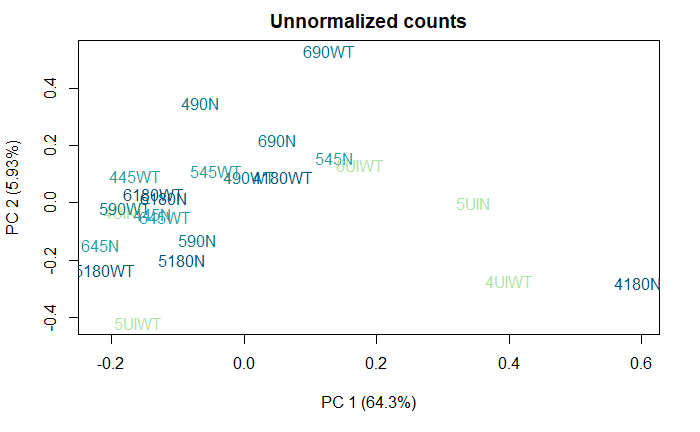

```r
#Use EDAseq to normalize the libraries
c_mat <- counts_simple %>%
                     dplyr::select(-dplyr::last_col()) %>%
                     dplyr::slice(-1:-4) %>%
                     as.matrix()
rownames(c_mat) <- counts_simple$Gene_ID [-1:-4]
pData <- data.frame(genotype=vector(mode = "logical", length = ncol(c_mat)),
                    timepoint = vector(mode = "logical", length = ncol(c_mat)),
                    samples = colnames(c_mat),
                    row.names = colnames(c_mat))
pData <- pData %>%
  mutate(genotype = case_when(
    str_detect(samples, "WT") ~ "WT",
    str_detect(samples, "UIN") ~ "WT",
    str_detect(samples, "N") ~ "N"
  ), timepoint = case_when(
    str_detect(samples, "UI") ~ 0,
    str_detect(samples, "45") ~ 45,
    str_detect(samples, "90") ~ 90,
    str_detect(samples, "180") ~ 180,
  ), group = str_c(genotype,timepoint,sep = ""),
  graph_cols = case_when(
    str_detect(samples, "UI") ~ carto_pal(n=6, cont_pal_choice) [2],
    str_detect(samples, "45") ~ carto_pal(n=6, cont_pal_choice) [4],
    str_detect(samples, "90") ~ carto_pal(n=6, cont_pal_choice) [5],
    str_detect(samples, "180") ~ carto_pal(n=6, cont_pal_choice) [6])) %>%
  dplyr::select(-samples)

data <- newSeqExpressionSet(counts=c_mat,
                            phenoData=pData)
#Normalize the data next
dataNorm <- betweenLaneNormalization(data, which="upper")
#For DE we will create this analysis with offset values
dataOffset <- betweenLaneNormalization(data,
                                       which="upper",offset=TRUE)
#Plot the counts
#pdf(here::here(str_c(res_path,"final RUV figures/Normalization effect on the library.pdf")), width = 8, height = 6)
graph_cols <- pData$graph_cols
plotPCA(data, col = graph_cols, main = "Unnormalized counts")
```

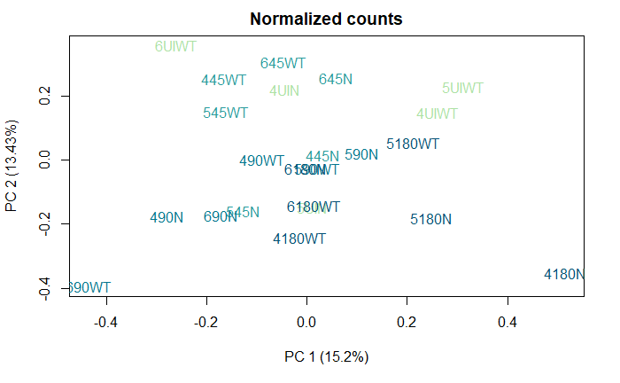

```r
plotPCA(dataOffset, col = graph_cols, main = "Normalized counts")
```

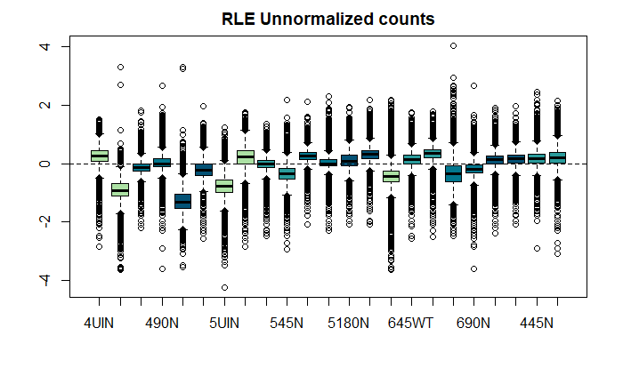

```r
plotRLE(data, col = graph_cols, main = "RLE Unnormalized counts")
```

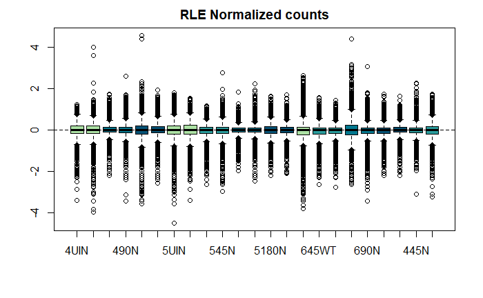

```r
plotRLE(dataOffset, col = graph_cols, main = "RLE Normalized counts")
```

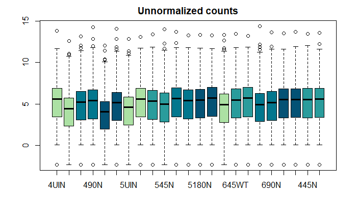

```r
boxplot(data, main = "Unnormalized counts", col = graph_cols)
```

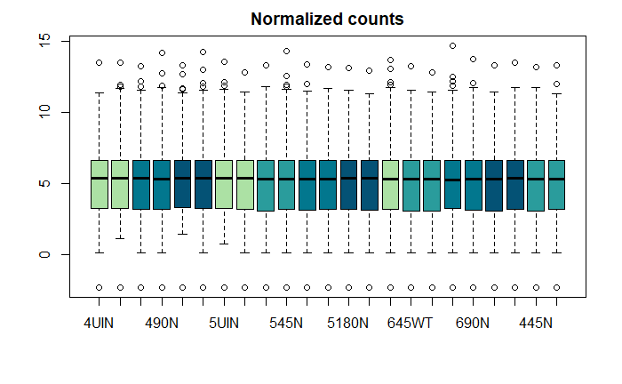

```r
boxplot(dataNorm, main = "Normalized counts", col = graph_cols)
```

```r
#dev.off()
```

Try RUV-Seq. First confirm that library size normalization helps somewhat with data, but not enough for clear separation of genotypes

Prepare the RUV-seq objects and perform RUVs normalization. Only testing the effects of this with 90 or 180 min, since 45 min would be too short to expect T3SS differences

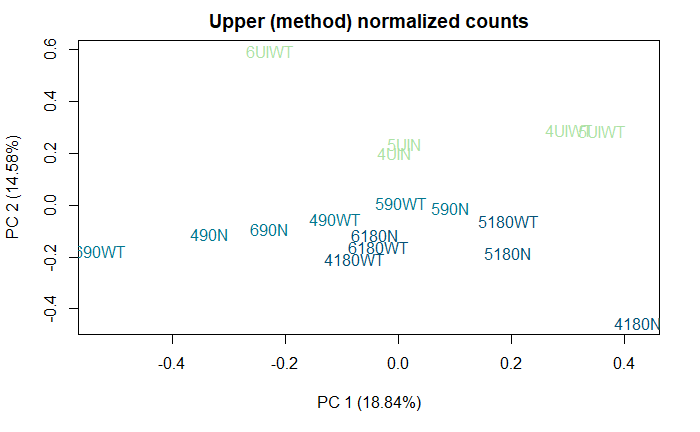

```r
scidx <- matrix(data = -1,  nrow = 5, ncol = 5)
scidx [1,] <- str_subset(rownames(pData),"UI")
scidx [2,1:3] <- str_subset(rownames(pData),"90WT")
scidx [3,1:3] <- str_subset(rownames(pData),"90N")
scidx [4,1:3] <- str_subset(rownames(pData),"180WT")
scidx [5,1:3] <- str_subset(rownames(pData),"180N")
cidx <- rownames(counts(data))
data_no45 <- newSeqExpressionSet(counts=c_mat [, str_detect(colnames(c_mat), "45", negate = T)],
                            phenoData=filter(pData, timepoint != 45))
dataOffset_no45 <- betweenLaneNormalization(data_no45,
                                       which="upper",offset=TRUE)
rv1 <- RUVs(dataOffset_no45, cidx, k=1, scidx, epsilon = 1, isLog = F)
rv2 <- RUVs(dataOffset_no45, cidx, k=2, scidx, epsilon = 1, isLog = F)
#pdf(here::here(str_c(res_path,"final RUV figures/Normalization effect on the library and RUV normalization.pdf")), width = 8, height = 6)
graph_cols <- pull(filter(pData, timepoint != 45),graph_cols)
plotPCA(dataOffset_no45, col = graph_cols, main = "Upper (method) normalized counts")
```

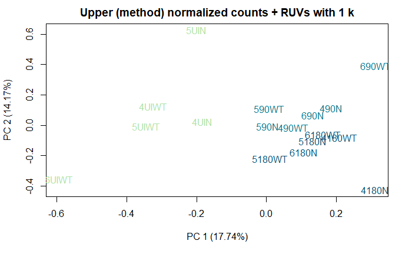

```r
plotPCA(rv1, col = graph_cols, main = "Upper (method) normalized counts + RUVs with 1 k")
```

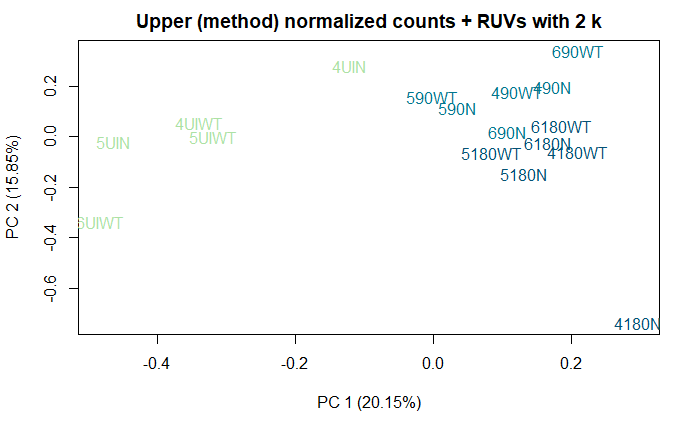

```r
plotPCA(rv2, col = graph_cols, main = "Upper (method) normalized counts + RUVs with 2 k")
```

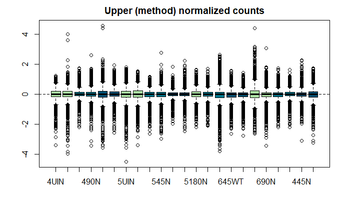

```r
plotRLE(dataOffset, col = graph_cols, main = "Upper (method) normalized counts")
```

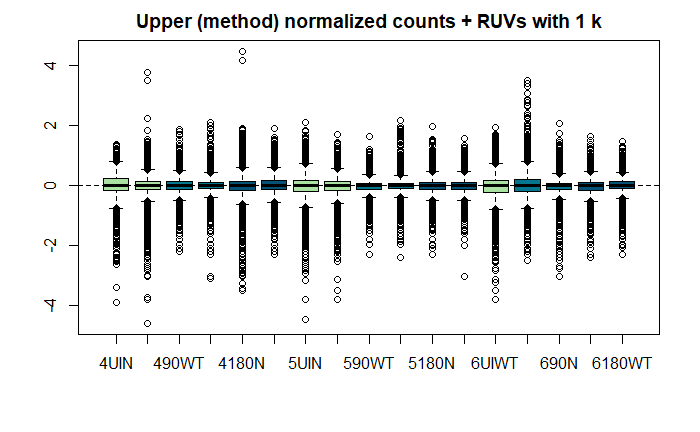

```r
plotRLE(rv1, col = graph_cols, main = "Upper (method) normalized counts + RUVs with 1 k")
```

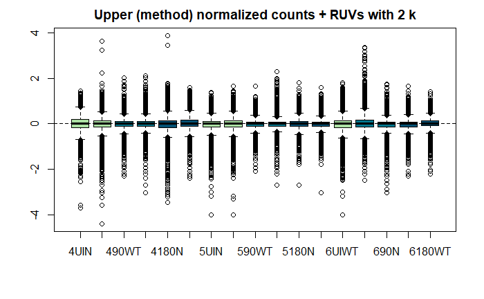

```r
plotRLE(rv2, col = graph_cols, main = "Upper (method) normalized counts + RUVs with 2 k")
```

```r
#dev.off()
```

#The RUV normalization is done, now we have normalization factors or weights, that can be fed into DESeq2 Keep an eye on this https://bioconductor.org/packages/release/workflows/vignettes/rnaseqGene/inst/doc/rnaseqGene.html#using-ruv-with-deseq2

```r
dds <- DESeqDataSetFromMatrix(countData = counts(dataOffset_no45),
                              colData = pData(dataOffset_no45),
                              design = ~  group)
```

Warning: some variables in design formula are characters, converting to factors

```r
dds$group <- relevel(dds$group, ref = "WT0")
normFactors <- exp(-1 * offst(dataOffset_no45))
normFactors <- normFactors / exp(rowMeans(log(normFactors)))
normalizationFactors(dds) <- normFactors
dds <- DESeq(dds)
```

using pre-existing normalization factors estimating dispersions gene-wise dispersion estimates mean-dispersion relationship final dispersion estimates fitting model and testing

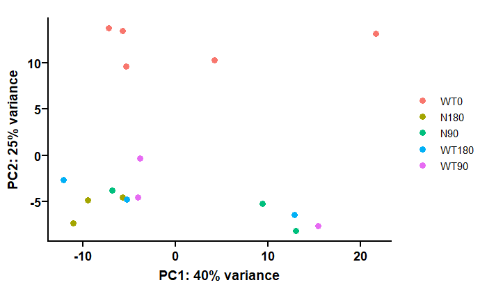

```r
rld <- vst(dds)
DESeq2::plotPCA(rld, intgroup = "group")
```

```r
resWTvsN <- results(dds, contrast = c("group","WT180", "N180"))
resWTvsUI <- results(dds, contrast = c("group","WT180", "WT0"))
walk(list(resWTvsUI,resWTvsN),summary)
```

out of 17187 with nonzero total read count adjusted p-value < 0.1 LFC > 0 (up) : 374, 2.2% LFC < 0 (down) : 212, 1.2% outliers [1] : 5, 0.029% low counts [2] : 1333, 7.8% (mean count < 7) [1] see ‘cooksCutoff’ argument of ?results [2] see ‘independentFiltering’ argument of ?results

out of 17187 with nonzero total read count adjusted p-value < 0.1 LFC > 0 (up) : 0, 0% LFC < 0 (down) : 0, 0% outliers [1] : 5, 0.029% low counts [2] : 0, 0% (mean count < 3) [1] see ‘cooksCutoff’ argument of ?results [2] see ‘independentFiltering’ argument of ?results

```r
dds1 <- DESeqDataSetFromMatrix(countData = counts(rv1),
                              colData = pData(rv1),
                              design = ~ W_1 + group)
```

Warning: some variables in design formula are characters, converting to factors

```r
normFactors <- exp(-1 * offst(dataOffset_no45))
normFactors <- normFactors / exp(rowMeans(log(normFactors)))
normalizationFactors(dds1) <- normFactors
dds1 <- DESeq(dds1)
```

using pre-existing normalization factors estimating dispersions gene-wise dispersion estimates mean-dispersion relationship final dispersion estimates fitting model and testing

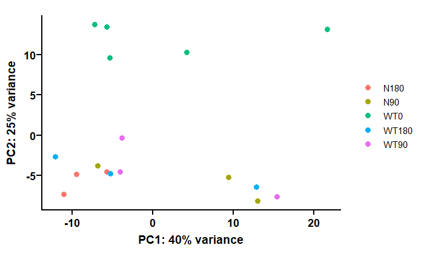

```r
rld1 <- vst(dds1)
DESeq2::plotPCA(rld1, returnData = F, intgroup = "group")
```

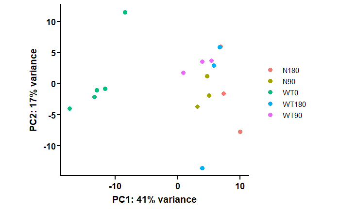

```r
mat <- limma::removeBatchEffect(assay(rld1),
                                covariates = rld1$W_1, design = model.matrix(~ genotype, colData(rld1)))
rld1.nobatch <- rld1
assay(rld1.nobatch) <- mat
DESeq2::plotPCA(rld1.nobatch, returnData = F, intgroup = "group")
```

```r
resWTvsN.1 <- results(dds1, contrast = c("group","WT180", "N180"))
resWTvsUI.1 <- results(dds1, contrast = c("group","WT180", "WT0"))
walk(list(resWTvsUI.1,resWTvsN.1),summary)
```

out of 17187 with nonzero total read count adjusted p-value < 0.1 LFC > 0 (up) : 505, 2.9% LFC < 0 (down) : 325, 1.9% outliers [1] : 0, 0% low counts [2] : 334, 1.9% (mean count < 5) [1] see ‘cooksCutoff’ argument of ?results [2] see ‘independentFiltering’ argument of ?results

out of 17187 with nonzero total read count adjusted p-value < 0.1 LFC > 0 (up) : 0, 0% LFC < 0 (down) : 0, 0% outliers [1] : 0, 0% low counts [2] : 0, 0% (mean count < 3) [1] see ‘cooksCutoff’ argument of ?results [2] see ‘independentFiltering’ argument of ?results

```r
#Now repeat with 2 factors accounted for:
dds2 <- DESeqDataSetFromMatrix(countData = counts(rv2),
                              colData = pData(rv2),
                              design = ~ W_1 + W_2 + group)
```

Warning: some variables in design formula are characters, converting to factors

```r
normalizationFactors(dds2) <- normFactors
dds2 <- DESeq(dds2)
```

using pre-existing normalization factors estimating dispersions gene-wise dispersion estimates mean-dispersion relationship final dispersion estimates fitting model and testing

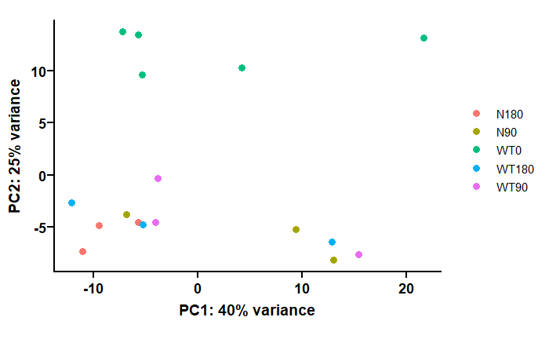

```r
rld2 <- vst(dds2)
DESeq2::plotPCA(rld2, returnData = F, intgroup = "group")
```

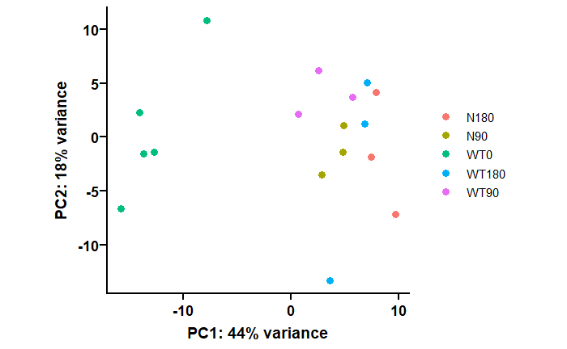

```r
mat <- limma::removeBatchEffect(assay(rld2),
                                covariates = matrix(data = c(rld2$W_1,rld2$W_2), ncol = 2),
                                design = model.matrix(~ genotype, colData(rld2)))
rld2.nobatch <- rld2
assay(rld2.nobatch) <- mat
DESeq2::plotPCA(rld2.nobatch, returnData = F, intgroup = "group")
```

```r
resWTvsN.2 <- results(dds2, contrast = c("group","WT180", "N180"))
resWTvsUI.2 <- results(dds2, contrast = c("group","WT180", "WT0"))
walk(list(resWTvsUI.2,resWTvsN.2),summary)
```

out of 17187 with nonzero total read count adjusted p-value < 0.1 LFC > 0 (up) : 665, 3.9% LFC < 0 (down) : 461, 2.7% outliers [1] : 0, 0% low counts [2] : 667, 3.9% (mean count < 6) [1] see ‘cooksCutoff’ argument of ?results [2] see ‘independentFiltering’ argument of ?results

out of 17187 with nonzero total read count adjusted p-value < 0.1 LFC > 0 (up) : 0, 0% LFC < 0 (down) : 0, 0% outliers [1] : 0, 0% low counts [2] : 0, 0% (mean count < 3) [1] see ‘cooksCutoff’ argument of ?results [2] see ‘independentFiltering’ argument of ?results

Generally, the differences between 1 and 2 factors are not that large. No comparisons uncover DE genes between WT and T3SS-mutant infected cells. Check how differentially expressed genes behave

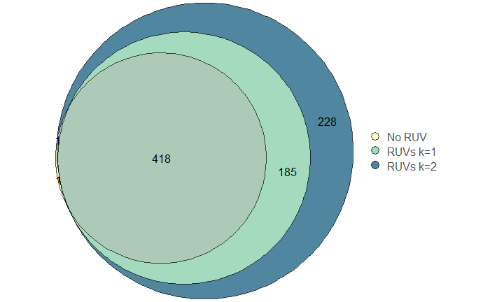

```r
wtvsn.res <- list(resWTvsUI, resWTvsUI.1,resWTvsUI.2) %>%
  map(as.data.frame) %>%
  map(~(filter(.,padj < 0.05))) %>%
  map(function(x) rownames(x))
names(wtvsn.res) <- c("No RUV","RUVs k=1","RUVs k=2")
#Visualize these results on a Venn diagram
#pdf(here::here(str_c(res_path,"final RUV figures/RUV effect on DE genes between WT and and 0min infection.pdf")), width = 8, height = 6)
eulerplot <- euler(wtvsn.res, shape = "circle")
plot(eulerplot, quantities = list(T, type = c("counts"), fontsize = 12),
     fills = c(carto_pal(7,"BluYl") [1],carto_pal(7,"BluYl") [3], carto_pal(7,"BluYl") [7]),
     adjust_labels = T, alpha = 0.7, legend = T, labels = F)
```

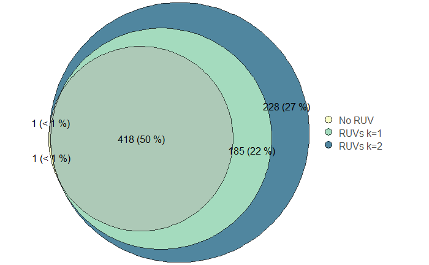

```r
plot(eulerplot, quantities = list(T, type = c("counts", "percent"), fontsize = 12),
     fills = c(carto_pal(7,"BluYl") [1],carto_pal(7,"BluYl") [3], carto_pal(7,"BluYl") [7]),
     adjust_labels = T, alpha = 0.7, legend = T, labels = F)
```

```r
#dev.off()
```

From this it is not clear that RUVs is very helpful in with this library prep. Keep it just to EDAseq normalization.

```r
p_list <- set_names(list(rld,rld1.nobatch,rld2.nobatch), nm = c("No RUV", "RUVs k=1", "RUVs k=2")) %>%
  map(~pca(assay(.x), colData(.x), removeVar = 0.1))
```

```
-- removing the lower 10% of variables based on variance
-- removing the lower 10% of variables based on variance
-- removing the lower 10% of variables based on variance
```

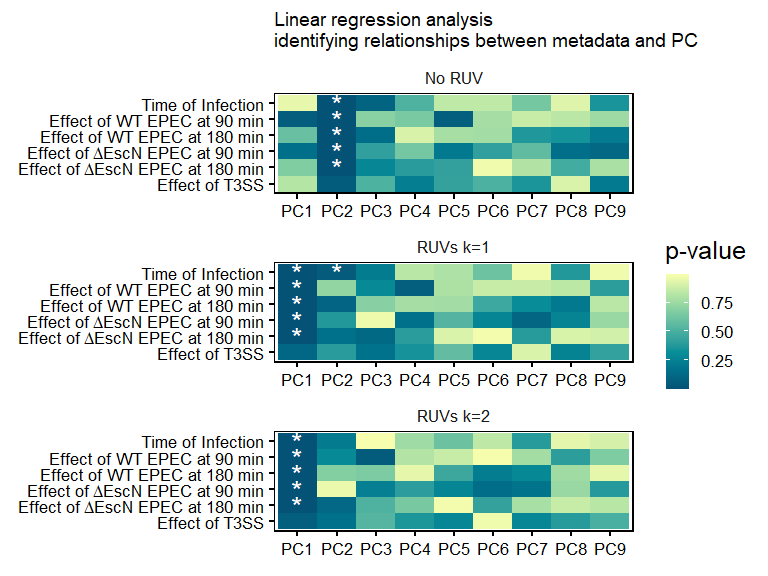

```r
pca_coord_meta_list <- p_list %>%
  map(~.x$rotated) %>%
  map2(list(rld,rld1.nobatch,rld2.nobatch), ~merge(.x,as.data.frame(colData(.y)), by = 0)) %>%
  map(mutate,
      group = fct_relevel(group, "WT0"),
      timepoint = as.numeric(timepoint),
      genotype = fct_relevel(genotype, "N"),)
#Create the lists to store information on the linear model performance
fit_list <- p_list
signi_list <- p_list
#Run the linear model for each PC - only first 9
for (i in seq_along(pca_coord_meta_list)) {
  pca_coord_meta_df <- pca_coord_meta_list [[i]]
  #Create a fit for each PC
  fit_list [[i]] <- set_names(vector(mode = "list", length = 9),
                              nm = str_c("PC",1:9))
  signi_list [[i]] <- set_names(vector(mode = "list", length = 9),
                                nm = str_c("PC",1:9))
  for (PC in seq_along(fit_list [[i]])) {
    fit_list [[i]] [[PC]] <- set_names(vector(mode = "list", length = 3),
                              nm = c("group", "timepoint", "genotype"))
    signi_list [[i]] [[PC]] <- set_names(vector(mode = "list", length = 3),
                              nm = c("group", "timepoint", "genotype"))
    for (metavar in c("group", "timepoint", "genotype")) {
      frm <- as.formula(str_c("PC",PC, " ~ ", metavar))
      fit_list [[i]] [[PC]] [[metavar]] <- lm(frm, data = pca_coord_meta_df)
      sum_of_fit <- summary(fit_list [[i]] [[PC]] [[metavar]])
      signi_list [[i]] [[PC]] [[metavar]] <- sum_of_fit$coefficients %>%
        as.data.frame() %>%
        mutate(R_squared = sum_of_fit$r.squared,
               PC = str_c("PC",PC),
               metavar = metavar) %>%
        rownames_to_column(var = "coef")
    }
  }
}
#Summarise liner model performance and plot the results
signi_list_reduced <- signi_list %>%
  map_depth(2,reduce,bind_rows) %>%
  map_depth(1, reduce,bind_rows) %>%
  map2(names(signi_list), ~mutate(.x, RUV = .y)) %>%
  purrr::reduce(bind_rows) %>%
  filter(coef != "(Intercept)") %>%
  dplyr::rename(p = `Pr(>|t|)`) %>%
  mutate(signi = case_when(
    p < 0.05 ~ "yes",
    TRUE ~ "no"
  ))
#Plot the results of regression
ggplot(signi_list_reduced) +
  geom_tile(aes(y=coef,x=PC, fill = p)) +
  geom_text(data = filter(signi_list_reduced, signi == "yes"), aes(y=coef,x=PC),
            label = "*", color = "white", size = 7, nudge_y = -0.02) +
  facet_wrap(~RUV, nrow = 3, scales = "free") +
  labs(x = element_blank(), y = element_blank(), title = "Linear regression analysis\nidentifying relationships between metadata and PC") +
  scale_y_discrete(labels = c(timepoint = "Time of Infection",
                              genotypeWT = "Effect of T3SS",
                              groupWT90 = "Effect of WT EPEC at 90 min",
                              groupWT180 = "Effect of WT EPEC at 180 min",
                              groupN90 = bquote("Effect of" ~ Delta*"EscN EPEC at 90 min"),
                              groupN180 = bquote("Effect of" ~ Delta*"EscN EPEC at 180 min"))) +
  scale_fill_carto_c(palette = "BluYl", direction = -1, name = "p-value") +
  theme_minimal(base_size = 16) +
  theme(panel.border = element_rect(fill = NA, color = "black"),
        axis.ticks.x = element_line(color = "black"),
        axis.ticks.y = element_line(color = "black"),
        panel.grid.major = element_blank(),
        axis.text = element_text(color = "black"),
        title = element_text(size = 12),
        legend.title = element_text(size = 19))
```

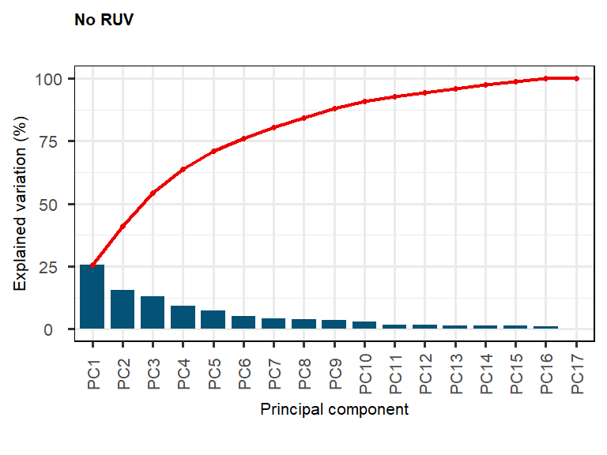

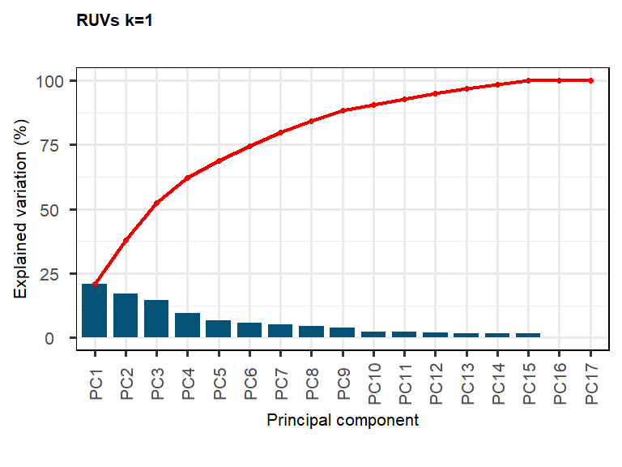

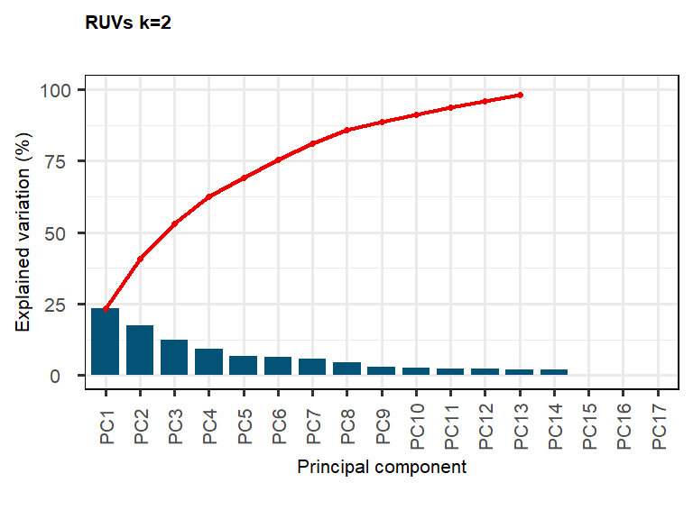

```r
#ggsave(here::here(str_c(res_path,"final RUV figures/Linear regression of metadata and PCA with respect to RUV.png")), width = 8,height = 6, dpi = 1080)
#Shifting correlations from PC2 to PC1 does not change much, as PC1 and PC2 explain about similar amounts of variation
#pdf(here::here(str_c(res_path,"final RUV figures/screeplots for each RUV approach.pdf")), width = 6, height = 5)
walk2(p_list, names(p_list),
      ~print(screeplot(.x, title = .y, colBar = carto_pal(2,cont_pal_choice) [2])))
```

```r
#dev.off()
```